# Correspondence Analysis

Erin M. Buchanan

Last Knitted: 2021-12-22

# Language Topics Discussed

- A reanalysis of color terms and categories

```r
##r chunk
library(reticulate)
```

# Basic Color Terms

- Berlin and Kay (1969) proposed a theory about our linguistic interpretations of colors, mainly that color vocabulary falls into universal categories
- Berlin and Kay’s work proposed that the specific color terms present in a culture are predictable by the number of terms they have.
- Everyone has black/white color words, then adds red, then yellow or green

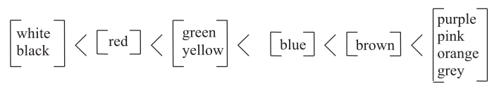

# Simple Correspondence Analysis

- Data is from the Corpus of Contemporary American English (COCA)
- Counts of adjective use of color terms

```r
##r chunk
library(Rling)
data(colreg)
head(colreg)
```

```
##        spoken fiction academic press
## black   20335   41118    26892 73080
## blue     4693   22093     3605 21210
## brown    1185   10914     1201 11539
## gray     1168   12140     1289  6559
## green    3860   14398     4477 26837
## orange    931    3496      474  5766
```

# Chi-square

- Chi-square analyses tell us if specific category frequencies are different than we might expect.
- Let’s look at a simple combination to understand the math behind chi-square.

```r
##r chunk
cs_example <- colreg[1:2, 1:2]
cs_example
```

```
##       spoken fiction
## black  20335   41118
## blue    4693   22093
```

# Expected values

$$E = \frac{Row*Column}{N}$$

```r
##r chunk
cs_example_e <- cs_example
rows <- rowSums(cs_example)
columns <- colSums(cs_example)

cs_example_e[1,1] <- rows[1]*columns[1]/sum(cs_example)
cs_example_e[1,2] <- rows[1]*columns[2]/sum(cs_example)
cs_example_e[2,1] <- rows[2]*columns[1]/sum(cs_example)
cs_example_e[2,2] <- rows[2]*columns[2]/sum(cs_example)
cs_example_e
```

```
##          spoken  fiction
## black 17430.452 44022.55
## blue   7597.548 19188.45
```

# Using `chisq.test`

```r
##r chunk
cs_test <- chisq.test(cs_example)
cs_test$expected
```

```
##          spoken  fiction
## black 17430.452 44022.55
## blue   7597.548 19188.45
```

```r
cs_example
```

```
##       spoken fiction
## black  20335   41118
## blue    4693   22093
```

# Chi-square Formula

$$\chi^2 = \Sigma \frac{(O-E)^2}{E}$$

```r
##r chunk
sum((cs_example - cs_example_e)^2 / cs_example_e)
```

```
## [1] 2225.712
```

```r
cs_test$statistic
```

```
## X-squared
##  2224.946
```

# Chi-Square - What Next?

- This test doesn’t tell you *what* was different though, much like ANOVA
- The way to know what cells were higher/lower than expected would be to use standardized residuals

# Residuals

- Residuals are $\frac{O-E}{\sqrt E}$, whereas standardized residuals are standardized format akin to z-scores

```r
##r chunk
cs_test$residuals #(cs_example - cs_example_e) / sqrt(cs_example_e)
```

```
##          spoken   fiction
## black  22.00008 -13.84334
## blue  -33.32282  20.96807
```

```r
cs_test$stdres
```

```
##          spoken   fiction
## black  47.17745 -47.17745
## blue  -47.17745  47.17745
```

# Mosaic Plots

- A visualization of the standardized residuals from a chi-square type analysis
- The box size is related to the observed cell size
- Coloring is shaded based on direction and strength of the residuals

# Mosaic Plots - Small Example

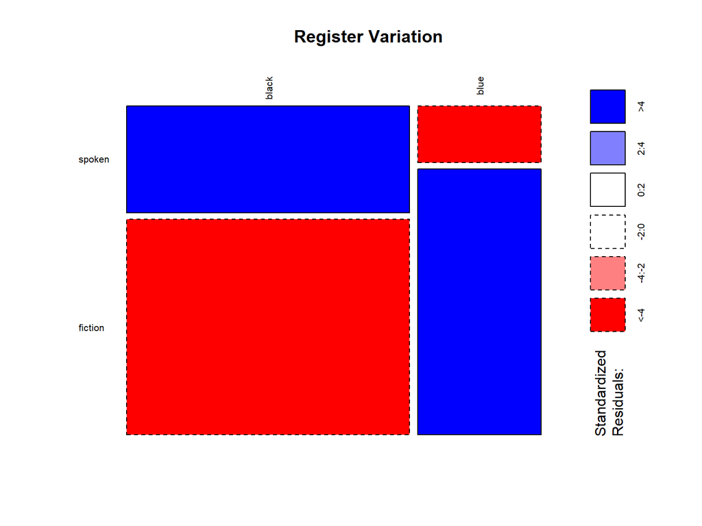

```r
##r chunk
mosaicplot(colreg[1:2, 1:2], #data frame
           las = 2, #axis label style (perpendicular)
           shade = T, #color in the boxes
           main = "Register Variation")
```

# Mosaic Plot - Full Data

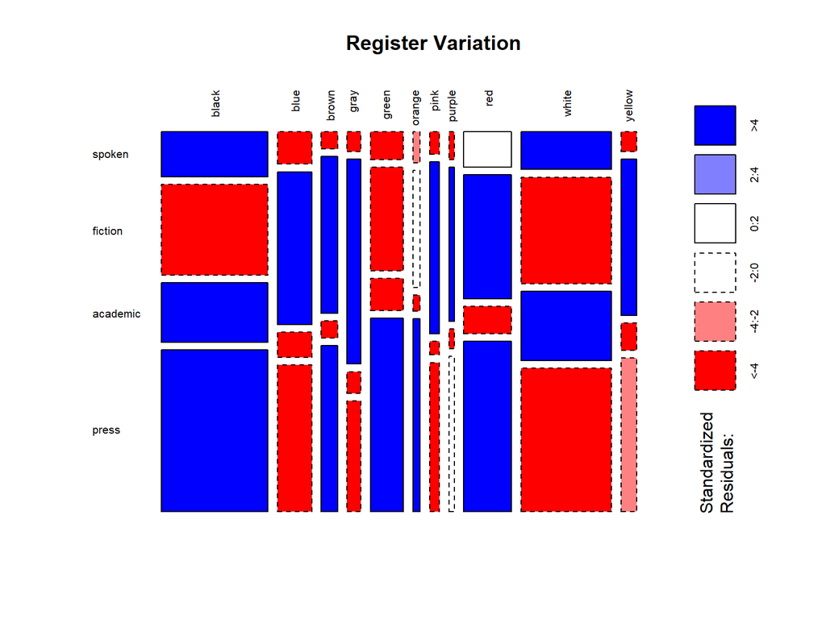

```r
##r chunk
mosaicplot(colreg, #data frame
           las = 2, #axis label style (perpendicular)
           shade = T, #color in the boxes
           main = "Register Variation")
```

# Simple Correspondence Analysis

- Identifies systematic relationships between variables in low dimensional space
- Similar to multidimensional scaling, principle components analysis, exploratory factor analysis

```r
##r chunk
library(ca)
sca_model <- ca(colreg)
```

# What’s in the output?

```r
##r chunk
summary(sca_model)
```

```
##
## Principal inertias (eigenvalues):
##
##  dim    value      %   cum%   scree plot
##  1      0.043730  77.9  77.9  *******************
##  2      0.010787  19.2  97.1  *****
##  3      0.001650   2.9 100.0  *
##         -------- -----
##  Total: 0.056167 100.0
##
##
## Rows:
##      name   mass  qlt  inr    k=1 cor ctr    k=2 cor ctr
## 1  | blck |  281  980  193 | -193 961 238 |   27  19  19 |
## 2  | blue |   90  947   89 |  226 919 105 |  -40  28  13 |
## 3  | brwn |   43  957   85 |  323 949 103 |   30   8   4 |
## 4  | gray |   37  999  176 |  443 733 165 | -267 267 244 |
## 5  | gren |   86  890   65 |   44  45   4 |  189 845 284 |
## 6  | orng |   19  999   25 |  166 362  12 |  221 637  84 |
## 7  | pink |   26 1000   67 |  374 989  85 |  -39  11   4 |
## 8  | prpl |   14  992   18 |  271 992  23 |    3   0   0 |
## 9  |  red |  126  936   50 |  110 548  35 |   93 388 101 |
## 10 | whit |  237  978  180 | -175 721 167 | -105 257 241 |
## 11 | yllw |   42  951   53 |  257 925  63 |  -43  25   7 |
##
## Columns:
##     name   mass  qlt  inr    k=1 cor ctr    k=2 cor ctr
## 1 | spkn |   99  769  102 | -211 766 100 |   15   4   2 |
## 2 | fctn |  332 1000  363 |  230 860 400 |  -93 140 265 |
## 3 | acdm |  126  992  441 | -415 882 499 | -147 110 252 |
## 4 | prss |  442  976   95 |   -7   4   0 |  108 973 481 |
```

# Inertia

- Top part is the table of inertias, which explain how much variance is accounted for by each dimension
- These are similar to eigenvalues that we will cover more with factor analyses

# Inertia

- Try to represent the relationship between variables in as few dimensions as possible
- Here we see that the first two dimensions capture 97% of the variance
- And the third dimension captures all the variance

Principal inertias (eigenvalues):

dim value % cum% scree plot  
1 0.043730 77.9 77.9 *******************  
2 0.010787 19.2 97.1 *****  
3 0.001650 2.9 100.0 *  
——– —–  
Total: 0.056167 100.0

# Visualize the Dimensions

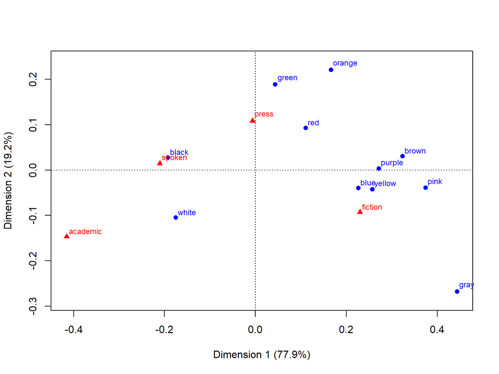

```r
##r chunk
plot(sca_model)
```

# Key Differences

- How are these plots different than the ones we’ve been making?
  - Terms are close together if they have similar frequency counts
  - This means the rows have similar *profiles* - rather than similar relationships to a latent variable
  - The distances on the map are a representation of the $\chi^2$ values of each row/column to the average profile

# Does this match theory?

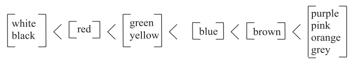

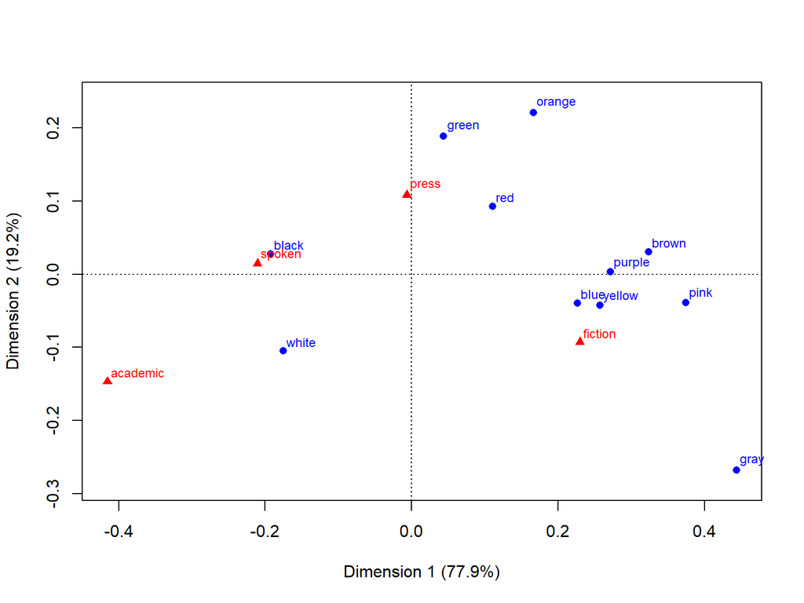

# Some other interesting notes

- Press is close to green-red because of the political orientation for these terms and proper names (Red Cross/Green Bay Packers)
- Fiction is likely close to the later color terms because of the requirement to “paint a picture” for readers
- Appears academics and spoken speech are pretty boring in their use of color terms

# How do we analyze CA in Python?

```python
##python chunk
import prince
```

[output not shown]

```python
col_reg = r.colreg #convert the data over from R

ca = prince.CA( ##set up the ca model
    n_components=2,
    n_iter=3,
    copy=True,
    check_input=True,
    engine='auto',
    random_state=42)

ca = ca.fit(col_reg) #run the ca model

ca.explained_inertia_ #get the inertias
```

```
## [0.7785699921774146, 0.19204556560171934]
```

# How do we graph CA in Python?

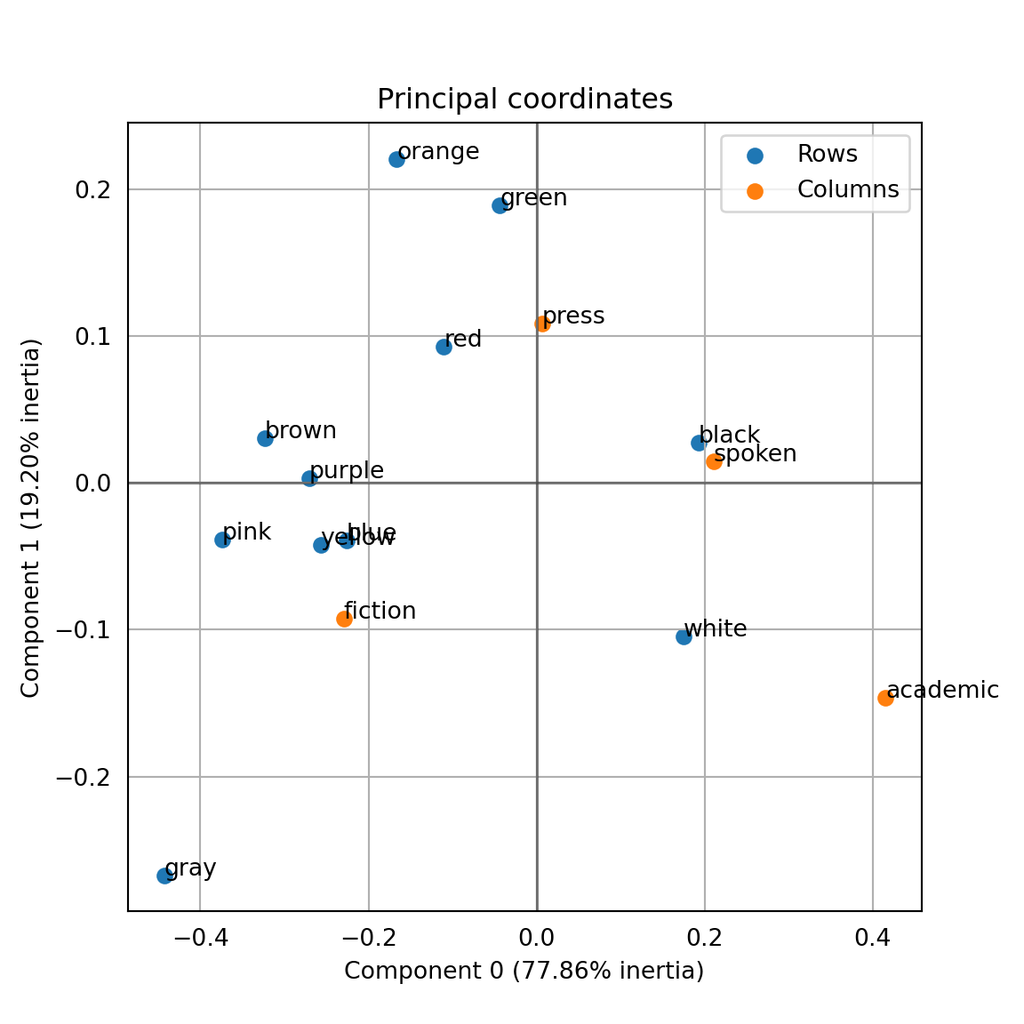

```python
##python chunk
import matplotlib
matplotlib.use('Agg')
ax = ca.plot_coordinates(
    X=col_reg,
    ax=None,
    figsize=(6, 6),
    x_component=0,
    y_component=1,
    show_row_labels=True,
    show_col_labels=True
)
ax.get_figure()
```

# 3D Plots in R

```r
##r chunk
plot3d.ca(sca_model, #model
       labels = c(1,1)) #see both row and column labels
```

[output not shown]

# A Category Example

- Is there a difference between the categories for *stuhl* (chair) and *sessel* (armchair)?
- Gipper (1959) had subjects name pictures of chairs to determine their relative frequencies
- The difference appeared to be that chairs are functional, while armchairs are about comfort

# The Data

- Data was coded from an online shopping place based on their text descriptions and other chair related variables

```r
##r chunk
data(chairs)
head(chairs)
```

```
##              Shop                   WordDE Category Function      Age Back Soft
## 1 Moebel-Profi.de                 3D-Stuhl    Stuhl      Eat    Adult  Low   No
## 2         ikea.de              Jugendstuhl    Stuhl      Eat Children  Mid   No
## 3         ikea.de                   Sessel   Sessel  NotSpec    Adult  Mid   No
## 4 Moebel-Profi.de               Swingstuhl    Stuhl      Eat    Adult High  Yes
## 5         ikea.de Kinderstuhl_mit_Sitzgurt    Stuhl      Eat Children High   No
## 6       roller.de                Drehstuhl    Stuhl     Work    Adult High  Yes
##   Arms Upholst MaterialSeat SeatHeight SeatDepth Swivel Roll Rock AddFunctions
## 1   No      No      Plastic       Norm      Norm     No   No   No           No
## 2   No      No         Wood       High      Norm     No   No   No           No
## 3  Yes      No       Rattan       Norm      Norm     No   No   No           No
## 4   No     Yes       Fabric       Norm      Norm     No   No   No           No
## 5  Yes      No      Plastic       High      Norm     No   No   No           No
## 6  Yes     Yes       Fabric     Adjust      Deep    Yes  Yes   No           No
##   Recline ReclineBack SaveSpace
## 1      No          No        No
## 2      No          No        No
## 3      No          No     stack
## 4      No          No        No
## 5      No          No        No
## 6      No          No        No
```

# Multiple Correspondence Analysis

```r
##r chunk
library(FactoMineR)
mca_model <- MCA(chairs[ , -c(1:3)], #dataset minus the first columns
                graph = FALSE)
summary(mca_model)
```

```
##
## Call:
## MCA(X = chairs[, -c(1:3)], graph = FALSE)
##
##
## Eigenvalues
##                        Dim.1   Dim.2   Dim.3   Dim.4   Dim.5   Dim.6   Dim.7
## Variance               0.325   0.258   0.135   0.123   0.109   0.096   0.090
## % of var.             15.298  12.126   6.362   5.785   5.125   4.526   4.244
## Cumulative % of var.  15.298  27.423  33.785  39.570  44.696  49.222  53.466
##                        Dim.8   Dim.9  Dim.10  Dim.11  Dim.12  Dim.13  Dim.14
## Variance               0.086   0.082   0.073   0.071   0.065   0.061   0.060
## % of var.              4.056   3.843   3.419   3.325   3.079   2.893   2.844
## Cumulative % of var.  57.523  61.365  64.784  68.109  71.188  74.081  76.925
##                       Dim.15  Dim.16  Dim.17  Dim.18  Dim.19  Dim.20  Dim.21
## Variance               0.055   0.051   0.050   0.045   0.044   0.039   0.036
## % of var.              2.565   2.400   2.338   2.105   2.071   1.844   1.694
## Cumulative % of var.  79.490  81.890  84.228  86.333  88.404  90.248  91.942
##                       Dim.22  Dim.23  Dim.24  Dim.25  Dim.26  Dim.27  Dim.28
## Variance               0.031   0.024   0.022   0.018   0.016   0.014   0.012
## % of var.              1.481   1.149   1.033   0.868   0.769   0.653   0.556
## Cumulative % of var.  93.423  94.572  95.605  96.473  97.242  97.895  98.451
##                       Dim.29  Dim.30  Dim.31  Dim.32  Dim.33  Dim.34
## Variance               0.009   0.009   0.005   0.005   0.003   0.001
## % of var.              0.439   0.434   0.252   0.231   0.149   0.044
## Cumulative % of var.  98.891  99.325  99.576  99.807  99.956 100.000
##
## Individuals (the 10 first)
##                Dim.1    ctr   cos2    Dim.2    ctr   cos2    Dim.3    ctr
## 1           |  0.784  1.005  0.195 |  0.197  0.080  0.012 | -0.041  0.007
## 2           |  0.867  1.231  0.265 |  0.355  0.260  0.044 | -0.899  3.181
## 3           |  0.797  1.038  0.230 |  0.042  0.004  0.001 |  0.566  1.258
## 4           |  0.017  0.000  0.000 | -0.029  0.002  0.001 | -0.196  0.151
## 5           |  0.665  0.723  0.136 |  0.298  0.183  0.027 | -0.779  2.390
## 6           | -0.833  1.136  0.530 |  0.390  0.314  0.116 |  0.109  0.047
## 7           |  0.928  1.409  0.292 |  0.186  0.071  0.012 |  0.106  0.044
## 8           | -0.395  0.255  0.161 | -0.649  0.869  0.434 | -0.024  0.002
## 9           |  0.701  0.803  0.524 |  0.165  0.056  0.029 | -0.093  0.034
## 10          |  0.313  0.161  0.150 |  0.022  0.001  0.001 | -0.114  0.051
##               cos2
```

[output cut: 32 more lines]

```
## Back_High   |  -0.119   0.248   0.009  -1.269 |
## Back_Low    |  -0.290   0.124   0.003  -0.721 |
##
## Categorical variables (eta2)
##                Dim.1 Dim.2 Dim.3
## Function     | 0.692 0.786 0.319 |
## Age          | 0.065 0.028 0.244 |
## Back         | 0.367 0.144 0.028 |
## Soft         | 0.666 0.039 0.225 |
## Arms         | 0.215 0.051 0.013 |
## Upholst      | 0.729 0.054 0.038 |
## MaterialSeat | 0.745 0.106 0.421 |
## SeatHeight   | 0.396 0.525 0.412 |
## SeatDepth    | 0.209 0.647 0.060 |
## Swivel       | 0.409 0.261 0.028 |
```

# Plot the MCA

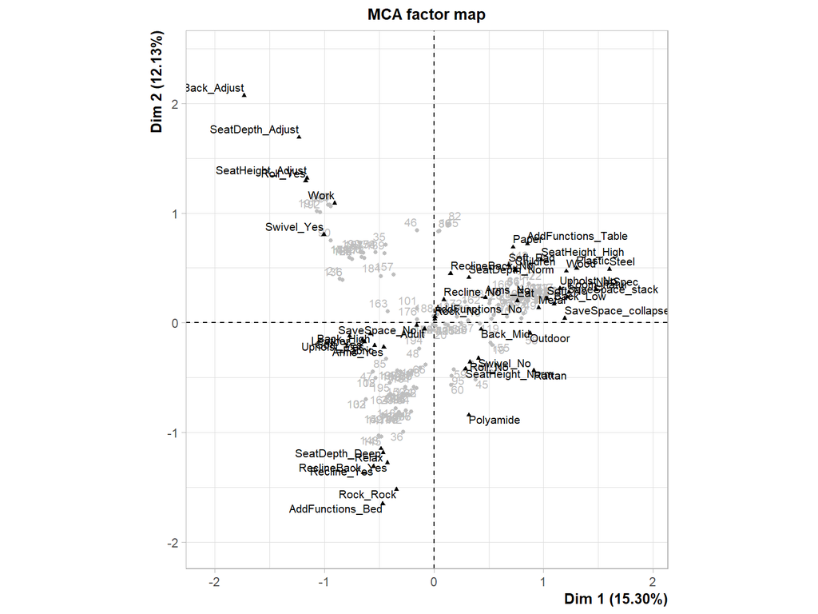

```r
##r chunk
plot(mca_model, cex = .7,
     col.var = "black",  #color the variable names
     col.ind = "gray")
```

```r
    # invis = "ind") #color the indicators
```

# How Useful are the Variables?

```r
##r chunk
dimdesc(mca_model)
```

```
## $`Dim 1`
## $quali
##                      R2
## Upholst      0.72940952
## MaterialSeat 0.74518860
## Function     0.69158437
## Soft         0.66568141
## Swivel       0.40875670
## Roll         0.38348403
## SeatHeight   0.39565748
## Back         0.36654364
## Arms         0.21473392
## SeatDepth    0.20909906
## SaveSpace    0.19444992
## Age          0.06521465
```

[output cut: 1399 more lines]

# Interpretation

- $R^2$ values representing the variables association with the dimension
- $p$ value strength of that association
- Then the `$category` section represents the directionality of the relationship
  - If this value is positive, shows on the right hand side of plot, representing a positive coefficient (and vice versa)

# Overall interpretation

- First dimension seems to represent comfort chairs versus not
- Second dimensions seems to represent functionality (work versus home)
- Third is harder to understand
- Appears to separate chairs into three categories:
  - Comfortable relaxation chairs
  - Comfortable adjustable chairs for work
  - Multifunctional chairs for the house

# Using the chair label

- We did not use the type of chair that is found in column 3 of our dataset
- We can map it onto our analysis using it as a supplementary variable

# Running that analysis

```r
##r chunk
mca_model2 <- MCA(chairs[ , -c(1,2)],
                 quali.sup = 1, #supplemental variable
                 graph = FALSE)
```

# Plot that analysis

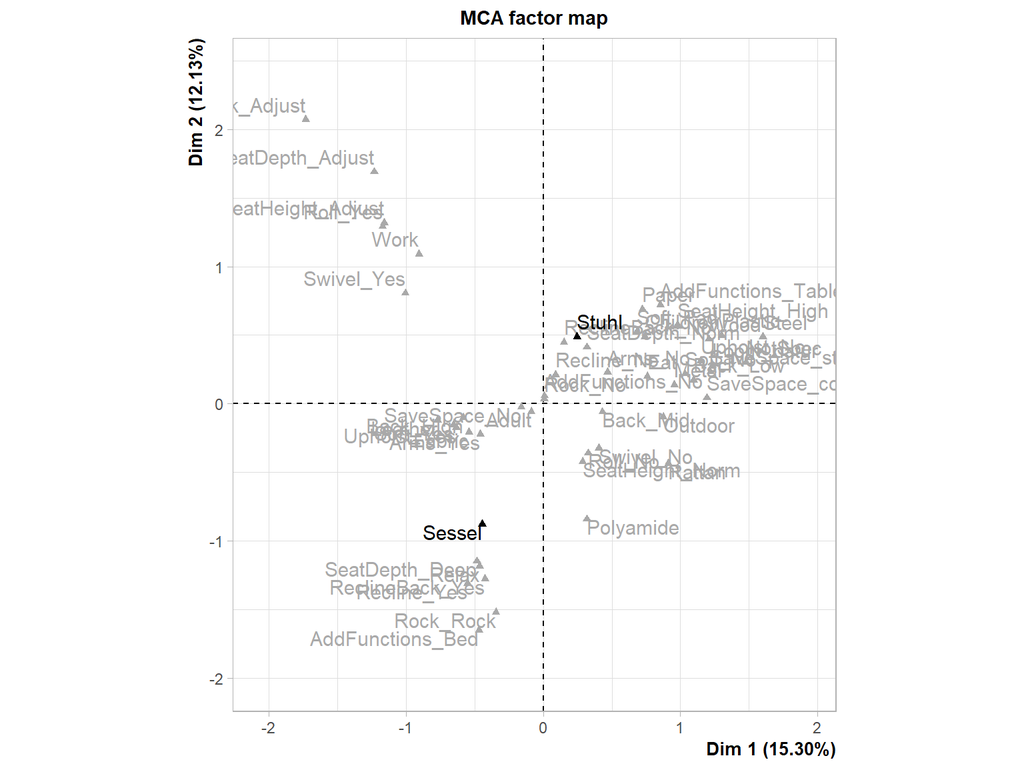

```r
##r chunk
plot(mca_model2, invis = "ind", col.var = "darkgray", col.quali.sup = "black")
```

```r
#the invis turned off the individual points
```

# Examine the prototypes

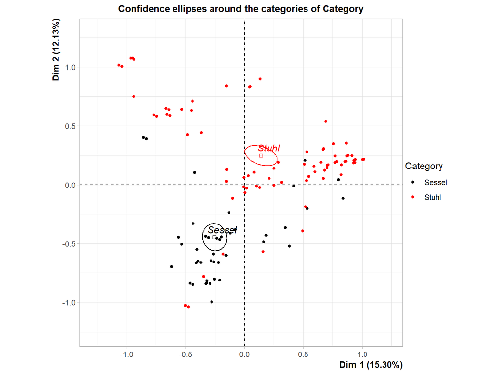

```r
##r chunk
plotellipses(mca_model2, keepvar = 1, #use column 1 to label
             label = "quali")
```

# Interpretation

- These confidence ellipses do not overlap, so we could consider the prototypes distinct entities
- We can also create a more traditional 95% CI type interval

# 95% Ellipses

- Now you can see that the categories themselves overlap a lot, so likely a representation of the fuzzy boundaries that categories appear to have.

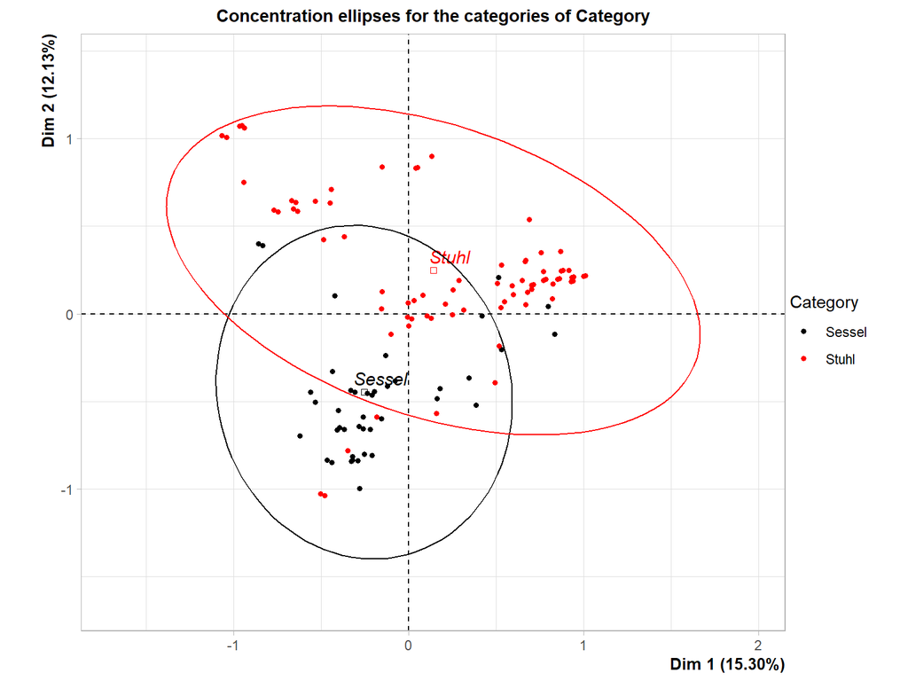

```r
##r chunk
plotellipses(mca_model2,
             means = F,
             keepvar = 1, #use column 1 to label
             label = "quali")
```

# The plot

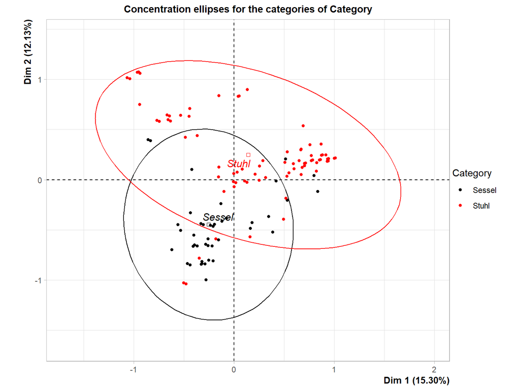

# But what about inertia?

```r
##r chunk
mca_model2$eig
```

```
##          eigenvalue percentage of variance cumulative percentage of variance
## dim 1  0.3250725720            15.29753280                          15.29753
## dim 2  0.2576755177            12.12590671                          27.42344
## dim 3  0.1351901997             6.36189175                          33.78533
## dim 4  0.1229322264             5.78504595                          39.57038
## dim 5  0.1089102792             5.12518961                          44.69557
## dim 6  0.0961853064             4.52636736                          49.22193
## dim 7  0.0901939195             4.24441974                          53.46635
## dim 8  0.0861985147             4.05640069                          57.52275
## dim 9  0.0816542710             3.84255393                          61.36531
## dim 10 0.0726465359             3.41866051                          64.78397
## dim 11 0.0706639812             3.32536382                          68.10933
## dim 12 0.0654187968             3.07853161                          71.18786
## dim 13 0.0614776588             2.89306630                          74.08093
## dim 14 0.0604269465             2.84362101                          76.92455
## dim 15 0.0545085623             2.56510882                          79.48966
## dim 16 0.0510037239             2.40017524                          81.88984
## dim 17 0.0496904953             2.33837625                          84.22821
## dim 18 0.0447356862             2.10520876                          86.33342
## dim 19 0.0440098756             2.07105297                          88.40447
## dim 20 0.0391756876             1.84356177                          90.24804
## dim 21 0.0359905329             1.69367213                          91.94171
## dim 22 0.0314725797             1.48106258                          93.42277
## dim 23 0.0244220420             1.14927256                          94.57204
## dim 24 0.0219417940             1.03255501                          95.60460
## dim 25 0.0184524392             0.86835008                          96.47295
## dim 26 0.0163375051             0.76882377                          97.24177
## dim 27 0.0138819275             0.65326717                          97.89504
## dim 28 0.0118208958             0.55627745                          98.45132
## dim 29 0.0093360630             0.43934414                          98.89066
## dim 30 0.0092222585             0.43398864                          99.32465
## dim 31 0.0053450573             0.25153211                          99.57618
## dim 32 0.0049065902             0.23089836                          99.80708
## dim 33 0.0031602962             0.14871982                          99.95580
## dim 34 0.0009392621             0.04420057                         100.00000
```

# Inertia part 2

```r
##r chunk
mca_model3 = mjca(chairs[ , -c(1:3)])
summary(mca_model3)
```

```
##
## Principal inertias (eigenvalues):
##
##  dim    value      %   cum%   scree plot
##  1      0.078443  47.1  47.1  **************
##  2      0.043342  26.0  73.2  ********
##  3      0.006012   3.6  76.8  *
##  4      0.004155   2.5  79.3  *
##  5      0.002451   1.5  80.8
##  6      0.001291   0.8  81.5
##  7      0.000873   0.5  82.1
##  8      0.000639   0.4  82.4
##  9      0.000417   0.3  82.7
##  10     0.000117   0.1  82.8
##  11     0.000076   0.0  82.8
```

[output cut: 57 more lines]

# MCA in Python

```python
##python chunk
mca = prince.MCA( ##set up the mca analysis
    n_components=2,
    n_iter=3,
    copy=True,
    check_input=True,
    engine='auto',
    random_state=42)

chairs = r.chairs
chairs = chairs.drop(['Shop', 'WordDE', 'Category'], axis=1)
mca = mca.fit(chairs)
mca.explained_inertia_
```

```
## [0.152972201030726, 0.12125657609697778]
```

# Plot MCA in Python

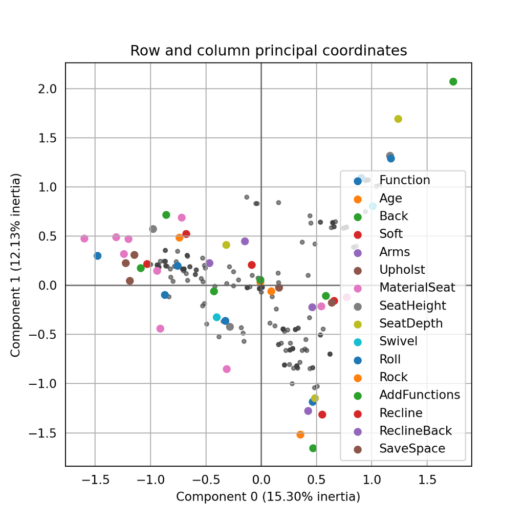

```python
##python chunk
ax = mca.plot_coordinates(
    X=chairs,
    ax=None,
    figsize=(6, 6),
    show_row_points=True,
    row_points_size=10,
    show_row_labels=False,
    show_column_points=True,
    column_points_size=30,
    show_column_labels=False,
    legend_n_cols=1
)
ax.get_figure()
```

# Further work

- From here, you could take the dimension scores `mca_model2$ind$coord` and use them to predict the categories or other variables
- This analysis would tell you how good at representing their categories each dimension does

# Summary

- We applied new models to basic color terms and category groupings
- We learned how to do simple and multiple correspondence analysis